# HW7

# 2. LDA approach

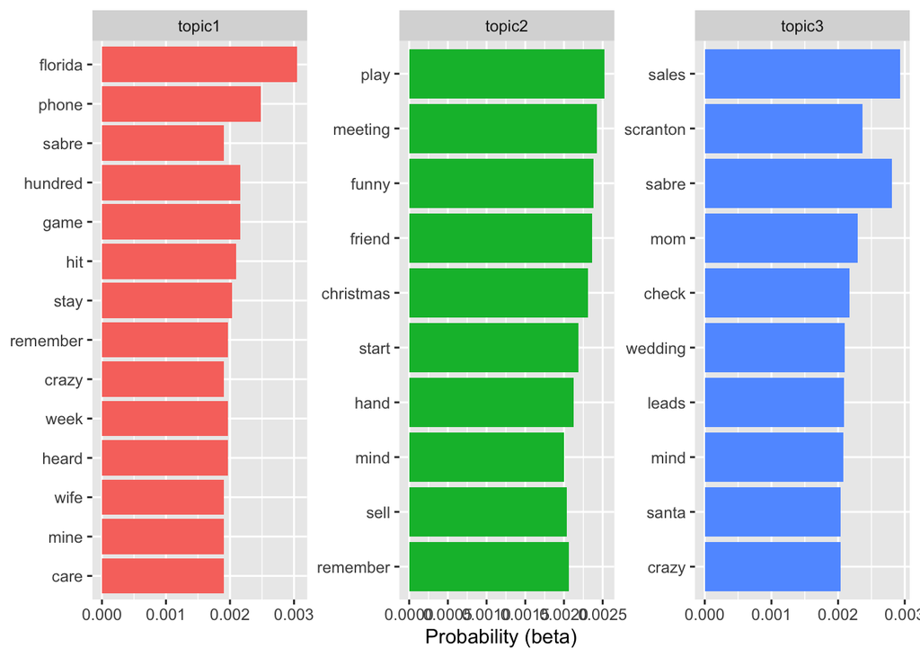

```r
office_stopwords_lda <- c(
    "michael", "jim", "pam", "dwight", "andy",
    "gould", "erin", "ryan", "jan", "toby",
    "stanley", "karen", "phyllis", "scott",
    "dunder", "mifflin", "feel", "told", "party",
    "darryl", "oscar", "angela", "meredith",
    "kevin", "huh", "whoa", "david", "mm", "bad",
    "robert", "gabe", "holly", "deangelo", "kelly",
    "nellie", "wanna", "ha", "gotta", "stuff",
    "charles", "la", "pete","yeah", "hey", "uh",
    "na", "um", "gonna", "hmm", "guy", "guys", "god",
    "time", "wait", "wow", "ah", "stop", "people",
    "office", "day", "alright", "nice", "talk",
    "cool", "fine", "nice", "job", "lot", "love",
    "call", "talking", "listening", "paper", "company",
    "fun", "listen", "thinking", "idea", "real",
    "pretty", "em", "business", "home", "manager",
    "baby", "night", "totally", "life", "bye", "car",
    "roy", "happy", "hear", "wrong", "hard", "hear",
    "called", "guess", "pum", "mike", "coming", "left",
    "leave", "head", "schrute", "lunch", "sounds", "da",
    "nope", "money", "bit", "meet", "hold", "tonight",
    "plan", "nope", "question", "friends", "weird",
    "hot", "morning", "boss"
)

office_words_lda <- theoffice |>
    group_by(season) |>
    summarise(text = paste(text, collapse = " ")) |>
    unnest_tokens(word, text) |>
    anti_join(stop_words, by = "word") |>
    filter(!word %in% office_stopwords_lda)

office_counts <- office_words_lda |>
    count(season, word)

office_dtm <- office_counts |>
    cast_dtm(document = season, term = word, value = n)

k <- 9
office_lda <- LDA(office_dtm, k = k, control = list(seed = 20250309))

office_topics <- tidy(office_lda, matrix = "beta") |>
    mutate(topic = paste0("topic", topic))

office_topics |>
    filter(topic %in% c("topic1","topic2","topic3")) |>
    group_by(topic) |>
    slice_max(beta, n = 10) |>
    ungroup() |>
    ggplot() +
    aes(beta, reorder(term, beta), fill = topic) +
    geom_col(show.legend = FALSE) +
    facet_wrap(~topic, scales = "free") +
    scale_y_reordered() +
    labs(x = "Probability (beta)",
         y = NULL)
```

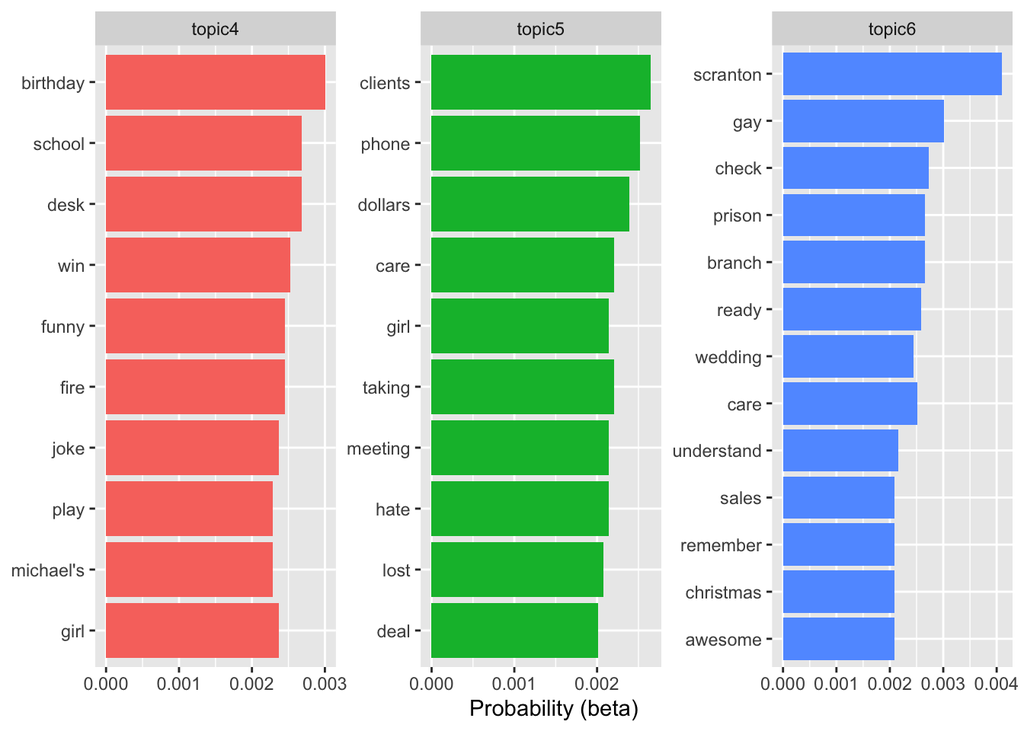

```r
office_topics |>
    filter(topic %in% c("topic4","topic5","topic6")) |>
    group_by(topic) |>
    slice_max(beta, n = 10) |>
    ungroup() |>
    ggplot() +
    aes(beta, reorder(term, beta), fill = topic) +
    geom_col(show.legend = FALSE) +
    facet_wrap(~topic, scales = "free") +
    scale_y_reordered() +
    labs(x = "Probability (beta)",
         y = NULL)
```

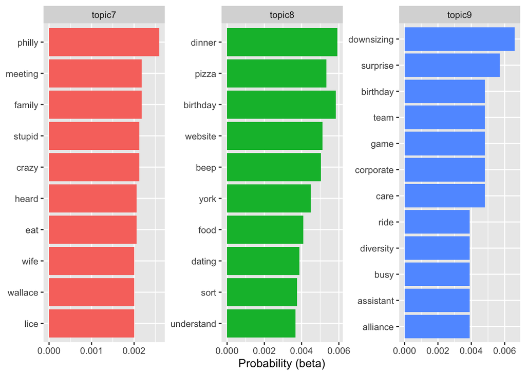

```r
office_topics |>
    filter(topic %in% c("topic7","topic8","topic9")) |>
    group_by(topic) |>
    slice_max(beta, n = 10) |>
    ungroup() |>
    ggplot() +
    aes(beta, reorder(term, beta), fill = topic) +
    geom_col(show.legend = FALSE) +
    facet_wrap(~topic, scales = "free") +
    scale_y_reordered() +
    labs(x = "Probability (beta)",
         y = NULL)
```

1: Florida, sabre, seasons 8/9  
2: Meetings, professional activities  
3: Pretty random assortment  
4: Pranking/joking around  
5: Business related activities  
6: Christmas parties, gay witch hunt, weddings  
7: Philly, lice, Wallace buying DM (possible S9)  
8: Eating, birthday parties, going on dates  
9: Downsizing, diversity, alliance (possible S1)

My strategy differed between TF-IDF and LDA. Since TF-IDF already recognized the season, I removed less words because character’s entries were relevant in certain seasons. However, when using the LDA approach, the program can’t recognize the season, so characters flood the topics. When using the LDA, I removed significantly more words to make the topics more clear. Still, I had trouble identifying the topics for LDA. I have more trouble understanding LDA.